# Fisseha Berhane, PhD

#### Data Scientist

fisseha@jhu.edu CV Resume

## Issues to pay attention to when performing PCA in Spark, Python and R

Principal component analysis (PCA) is a statistical analysis technique that transforms possibly correlated variables to orthogonal linearly uncorrelated values. We can use it for applications such as data compression, to get dominant physical processes and to get important features for machine learning. Without losing much information, it reduces the number of features in the original data.

Recently, I was using PCA with Spark with sparse matrix with millions of rows and to make sure everything was right I first started with a small dataset and compared the results from Spark, Python and R which led to this blog post.

In this post, I will cover data prepocessing required and how to implement PCA in R, Python and Spark and how to translate the results.

The calculation is done using singular value decomposition (SVD). The SVD of any m x n matrix is calculated as

$A = U \sum V^{T}$

where U is an m × m orthogonal matrix whose columns are the eigenvectors of $AA^{T}$ , V is an n × n orthogonal matrix whose columns are the eigenvectors of $A^{T}A$, and Σ is an m × n diagonal matrix and its values are zero except along the diagonal.

When applying PCA, we have to center our data that is we have to subtract the column mean. Next, based on the nature of our data, we may need to standardize our data (make each feature have a unit variance and zero mean). If the columns are in different scales such as year, temperature, carbondioxide concentration, for example, we have to standardize the data. If the data is in the same unit, on the other hand, standardizing it can result in loss of important information. In the first case, when the columns are in the same unit and in similar scale, we use the covariance matrix for SVD but when the units are different since we standardize the data, we use the correlation matrix.

The principal components (PCs) are the matrix product of the original data and the matrix V which is equal to the product of matrixes U and ∑.

### Variables in the same unit

For this example, we will use the iris data. The data set consists of 50 samples from each of three species of Iris (Iris setosa, Iris virginica and Iris versicolor). Each sample has four features: the length and the width of the sepals and petals, in centimeters. You can get the data, including details, from [UCI Machine Learning Repository](https://archive.ics.uci.edu/ml/datasets/iris). I downloaded the data from [here](https://raw.githubusercontent.com/venky14/Machine-Learning-with-Iris-Dataset/master/Iris.csv)

```python
options(repr.plot.width=8, repr.plot.height=5)
```

### R

```python
library(tidyverse)
library(readr)
library(data.table)
options(readr.num_columns = 0)
library(corrplot)
```

```python
iris = read_csv("https://raw.githubusercontent.com/venky14/Machine-Learning-with-Iris-Dataset/master/Iris.csv")
```

```python
head(iris)    # show sample records
```

| Id | SepalLengthCm | SepalWidthCm | PetalLengthCm | PetalWidthCm | Species |
| --- | --- | --- | --- | --- | --- |
| 1 | 5.1 | 3.5 | 1.4 | 0.2 | Iris-setosa |
| 2 | 4.9 | 3.0 | 1.4 | 0.2 | Iris-setosa |
| 3 | 4.7 | 3.2 | 1.3 | 0.2 | Iris-setosa |
| 4 | 4.6 | 3.1 | 1.5 | 0.2 | Iris-setosa |
| 5 | 5.0 | 3.6 | 1.4 | 0.2 | Iris-setosa |
| 6 | 5.4 | 3.9 | 1.7 | 0.4 | Iris-setosa |

All the units are in cm. Since we do not need the Id and Species columns for our analysis, let's drop them.

```python
species = iris$Species                 # creating a vector to use it later
iris = iris %>% select(-Id,-Species)
```

Since the columns are in the same scale, we do not need to scale it: just centering the columns is enough (SVD uses covariance matrix in this case). As shown below, we can specify if we want to center it or scale it.

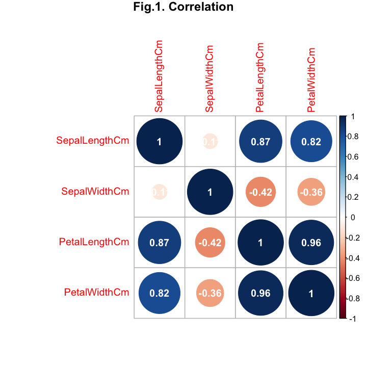

```python
correlations = cor(iris)
corrplot(correlations, method="circle", addCoef.col = "white",
         title = 'Fig.1. Correlation', mar=c(0,0,1,0))
```

As shown in Fig.1. above, some of the variables are strongly correlated. This means we can reduce the dimensionality with out losing information. When the variables are strongly correlated, the first few PCs explain large portion of the variability in the data. When applying PCA with R, Python or Spark, we have to make sure that the rows are samples and the columns are variables.

#### Apply PCA

```python
pcp = prcomp(iris, center = TRUE, scale. = FALSE)  # center it but do not scale it
```

The **prcomp** function uses SVD and returns the following:

1. x: principal components which are the matrix product of the original data and the rotation: x = df %*% rotation
2. sdev: standard deviation scaled by sample size in an unbiased way (ie. 1/(n-1))
3. rotation: loadings of each principal component

#### Variance Explained

The variance explained by each PC is shown below. The PCs are ranked based on the variance they explain: the first PC explains the highest variance, followed by the second PC and so on.

So, we see that the first PC explains almost all the variance (92.4616%) while the fourth PC explains only 0.5183%. In such scenarios where we have many columns and the first few PCs account for most of the variability in the original data (such as 95% of the variance), we can use the first few PCs for data explorations and for machine learning. In data explorations, we can visualize the PCs and get a better understanding of processes using those PCs. In machine learning, on the other hand, by using the PCs, we will work with less number of columns and this can significantly reduce computational cost and help in reducing over-fitting. It is important to mention here that when you use PCA for machine learning, the test data should be transformed using the loading vectors found from the training data otherwise your model will have difficulty generalizing to unseen data.

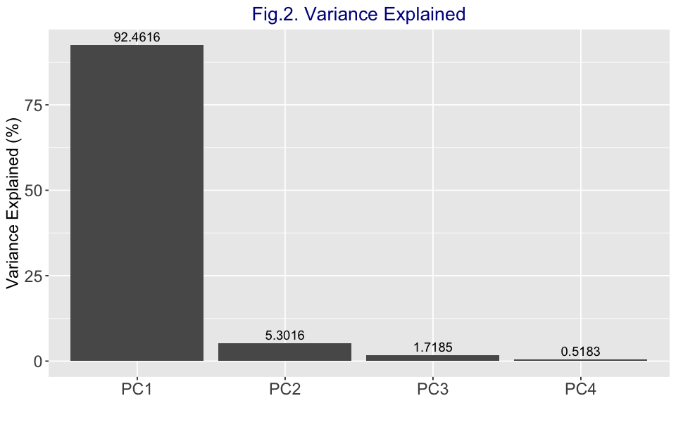

```python
variance = data_frame(PC = paste0('PC', seq(1,4)), variance = round(100.00*pcp$sdev^2/sum(pcp$sdev^2),4))
variance %>% ggplot(aes(x = PC, y = variance)) + geom_bar(stat = 'identity') + ggtitle('Fig.2. Variance Explained') +
theme(axis.title = element_text(size=14), plot.title = element_text(size = 16,colour="darkblue", hjust = 0.5),
axis.text = element_text(size=14)) + geom_text(aes(label = variance), vjust = -0.4) + xlab('') +
ylab('Variance Explained (%)')
```

#### Loadings

We can see which variables have the largest effects in each PC from the rotations (loadings). The features which have the highest magnitude of loadings in the first PC have the highest effect. From the loading of the iris data below, we observe that petal length has the highest effect in the first PC while in the second PC sepal length and sepal width are the most important. If two features have similar loadings in the first and the second PCs, the one in the first PC is more important. Generally, for similar loadings, features in the $n^{th} -1$ PC are more important than those in the $n^{th}$ PC.

```python
round(pcp$rotation, 4)
```

|  | PC1 | PC2 | PC3 | PC4 |
| --- | --- | --- | --- | --- |
| SepalLengthCm | 0.3616 | -0.6565 | 0.5810 | 0.3173 |
| SepalWidthCm | -0.0823 | -0.7297 | -0.5964 | -0.3241 |
| PetalLengthCm | 0.8566 | 0.1758 | -0.0725 | -0.4797 |
| PetalWidthCm | 0.3588 | 0.0747 | -0.5491 | 0.7511 |

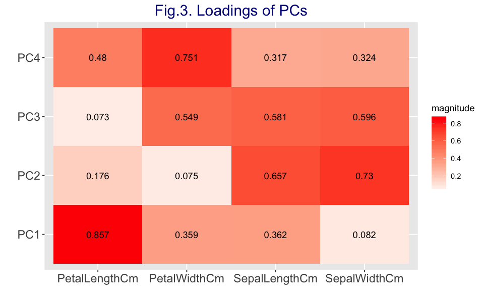

```python
rotation = as.data.frame(pcp$rotation)
rotation$dimension = row.names(rotation)
rotation = rotation %>% melt(key = dimension, value = pc) %>% mutate(magnitude = abs(value))
rotation %>% ggplot(aes(x  = dimension, y = variable , fill = magnitude)) + geom_tile()+xlab('') + ylab('') +
scale_fill_gradient2(low = "sky blue", high = "red") + ggtitle('Fig.3. Loadings of PCs') +
theme(axis.title = element_text(size=14), plot.title = element_text(size = 18,colour="darkblue", hjust = 0.5),
axis.text = element_text(size=14)) + geom_text(aes(label = round(magnitude,3)))
```

#### Principal components (PCs)

Sample values from the PCs are shown below to help us compare with the results from Python and Spark.

```python
round(head(pcp$x,10),5)
```

| PC1 | PC2 | PC3 | PC4 |
| --- | --- | --- | --- |
| -2.68421 | -0.32661 | 0.02151 | 0.00101 |
| -2.71539 | 0.16956 | 0.20352 | 0.09960 |
| -2.88982 | 0.13735 | -0.02471 | 0.01930 |
| -2.74644 | 0.31112 | -0.03767 | -0.07596 |
| -2.72859 | -0.33392 | -0.09623 | -0.06313 |
| -2.27990 | -0.74778 | -0.17433 | -0.02715 |
| -2.82089 | 0.08210 | -0.26425 | -0.05010 |
| -2.62648 | -0.17041 | 0.01580 | -0.04628 |
| -2.88796 | 0.57080 | -0.02734 | -0.02662 |
| -2.67384 | 0.10669 | 0.19153 | -0.05589 |

As shown below, the PCs are orthogonal to each other (their correlations are zero).

```python
round(cor(pcp$x), 5)
```

|  | PC1 | PC2 | PC3 | PC4 |
| --- | --- | --- | --- | --- |
| PC1 | 1 | 0 | 0 | 0 |
| PC2 | 0 | 1 | 0 | 0 |
| PC3 | 0 | 0 | 1 | 0 |
| PC4 | 0 | 0 | 0 | 1 |

We can also plot the PCs and color them by the species. Let's take the first two PCs, which account for about 98% of the variance, and see the pattern. We can observe from the figure below that using the first two PCs, we are able to identify two distinct clusters: one for setosa and another one for versicolor and viginica.

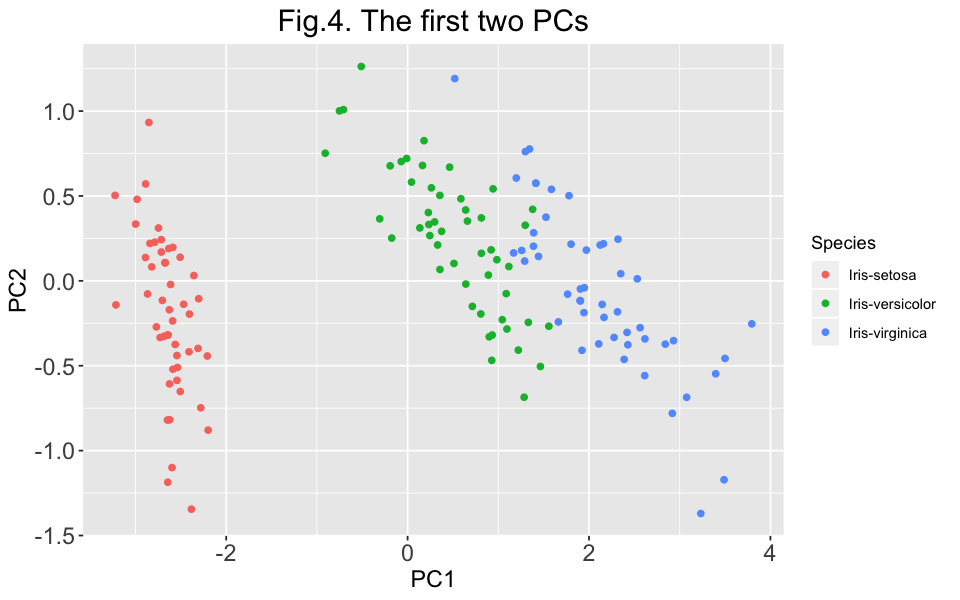

```python
df = as.data.frame(pcp$x)
df$Species = species
df %>% ggplot(aes(x = PC1, y = PC2, color = Species)) + geom_point() +
ggtitle('Fig.4. The first two PCs') + theme(axis.title = element_text(size=14),
                                     plot.title = element_text(size = 18, hjust = 0.5),
axis.text = element_text(size=14))
```

#### Let's quickly check the results using SVD

```python
scaled_data = scale(iris,center = TRUE, scale = FALSE )
my_svd  = svd(scaled_data)
```

#### The v matrix from svd is rotation in prcomp

```python
all(my_svd$v, pcp$rotation)
```

TRUE

#### The principal component from prcomp is the product of the original data and matrix v from svd.

```python
all(scaled_data %*% my_svd$v, pcp$x)
```

TRUE

#### For prcomp(), sdev = sqrt(var) = sqrt(ss(fit)/(n-1))

#### For svd(), d = sqrt(ss(fit))

```python
all(my_svd$d^2, pcp$x^2 * (nrow(scaled_data) - 1))
```

TRUE

### Python

In Python, unlike R, the PCA decomposition will not center or scale the input data automatically. There is no parameter that controls whether to center or scale the data. We have to process our data before applying PCA.

```python
from sklearn.decomposition import PCA
import pandas as pd
import numpy as np
import seaborn as sns
import matplotlib.pyplot as plt
plt.style.use('ggplot')
from sklearn.preprocessing import scale
%matplotlib inline
```

```python
df = pd.read_csv("https://raw.githubusercontent.com/venky14/Machine-Learning-with-Iris-Dataset/master/Iris.csv")
df.head()
```

|  | Id | SepalLengthCm | SepalWidthCm | PetalLengthCm | PetalWidthCm | Species |
| --- | --- | --- | --- | --- | --- | --- |
| 0 | 1 | 5.1 | 3.5 | 1.4 | 0.2 | Iris-setosa |
| 1 | 2 | 4.9 | 3.0 | 1.4 | 0.2 | Iris-setosa |
| 2 | 3 | 4.7 | 3.2 | 1.3 | 0.2 | Iris-setosa |
| 3 | 4 | 4.6 | 3.1 | 1.5 | 0.2 | Iris-setosa |
| 4 | 5 | 5.0 | 3.6 | 1.4 | 0.2 | Iris-setosa |

```python
df = df.drop(['Id','Species'], axis = 1)
```

Just to see how to do it in Python as well, let's create a correlation matrix heatmap. As I said above, strong correlation among variables means the first few PCs can explain most of the variation in the data and PCA could be a right application for such kind of datasets.

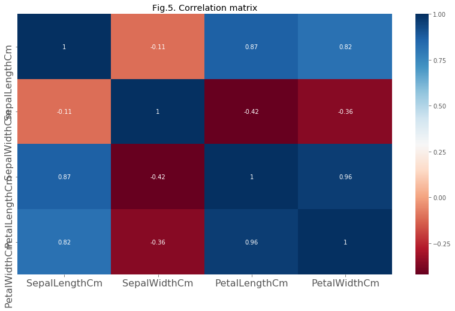

```python
corr = df.corr()
plt.figure(figsize = (14, 8))
sns.heatmap(corr, cmap="RdBu",annot = True,
            xticklabels=corr.columns.values,
            yticklabels=corr.columns.values)
plt.title('Fig.5. Correlation matrix')
plt.xticks(size = 16)
plt.yticks(size = 16)
plt.show()
```

Now, let's center the data using the scale function. As you can see below, since we are dealing with variables that have the same unit and similar scales, we do not need to standardize it.

#### Center data

```python
scaled = scale(df, with_mean=True, with_std=False)
```

What does the data look like when the mean of each column is subtracted from each value of each variable?

```python
scaled[:10,:]
```

```
array([[-0.74333333,  0.446     , -2.35866667, -0.99866667],
       [-0.94333333, -0.054     , -2.35866667, -0.99866667],
       [-1.14333333,  0.146     , -2.45866667, -0.99866667],
       [-1.24333333,  0.046     , -2.25866667, -0.99866667],
       [-0.84333333,  0.546     , -2.35866667, -0.99866667],
       [-0.44333333,  0.846     , -2.05866667, -0.79866667],
       [-1.24333333,  0.346     , -2.35866667, -0.89866667],
       [-0.84333333,  0.346     , -2.25866667, -0.99866667],
       [-1.44333333, -0.154     , -2.35866667, -0.99866667],
       [-0.94333333,  0.046     , -2.25866667, -1.09866667]])
```

Now, let's apply PCA using the centered data.

#### Apply PCA

```python
model = PCA()
model.fit(scaled)
transformed = model.transform(scaled)
```

#### Explained Variance

As shown below, the variance explained values we got from R and Python are the same.

```python
np.round(model.explained_variance_ratio_ * 100,4)
```

```
array([92.4616,  5.3016,  1.7185,  0.5183])
```

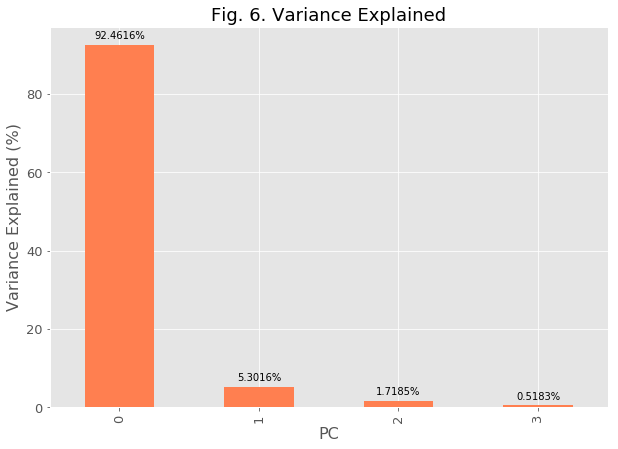

```python
var = pd.DataFrame ({'variance':np.round(model.explained_variance_ratio_ * 100,4),
                    'PC':['p' + str(i) for i in range(1,5)]})

ax = var.plot(kind='bar', figsize=(10,7), color="coral", fontsize=13, legend = False)
ax.set_alpha(0.8)
ax.set_title("Fig. 6. Variance Explained", fontsize=18)
ax.set_xlabel("PC", fontsize=16)
ax.set_ylabel("Variance Explained (%)", fontsize=16)

rects = ax.patches
labels = list(var['variance'])
labels = [str(variance) +'%' for variance in labels]


for rect, label in zip(rects, labels):
    height = rect.get_height()
    ax.text(rect.get_x() + rect.get_width() / 2, height + 1, label,
            ha ='center', va='bottom')
```

#### Loadings

The loadings are shown below. The result is an array and as compred to R and Spark, the array is transposed. It is important to note how to access each PCs loading.

```python
loadings = np.round(model.components_,4)
loadings
```

```
array([[ 0.3616, -0.0823,  0.8566,  0.3588],
       [ 0.6565,  0.7297, -0.1758, -0.0747],
       [-0.581 ,  0.5964,  0.0725,  0.5491],
       [ 0.3173, -0.3241, -0.4797,  0.7511]])
```

To access the loading of the first PC, we extract the first row and all the columns as shown below. Note: rows and columns of the loadings have been switched between the results from R and Python.

```python
loadings[0,]
```

```
array([ 0.3616, -0.0823,  0.8566,  0.3588])
```

#### Principal Components

A sample of the principal components are shown below. They are the same with the results from R and Spark. As expected, they are uncorrelated.

```python
np.set_printoptions(suppress=True)
transformed = np.round(transformed, 5)
transformed[:10,:]
```

```
array([[-2.68421,  0.32661, -0.02151,  0.00101],
       [-2.71539, -0.16956, -0.20352,  0.0996 ],
       [-2.88982, -0.13735,  0.02471,  0.0193 ],
       [-2.74644, -0.31112,  0.03767, -0.07596],
       [-2.72859,  0.33392,  0.09623, -0.06313],
       [-2.2799 ,  0.74778,  0.17433, -0.02715],
       [-2.82089, -0.0821 ,  0.26425, -0.0501 ],
       [-2.62648,  0.17041, -0.0158 , -0.04628],
       [-2.88796, -0.5708 ,  0.02734, -0.02662],
       [-2.67384, -0.10669, -0.19153, -0.05589]])
```

```python
np.round(np.corrcoef(transformed, rowvar=False),5) # If `rowvar` is True (default), then each row represents a
                                                   # variable, with observations in the columns. Otherwise, the relationship
                                                   # is transposed: each column represents a variable, while the rows
                                                   # contain observations.
```

```
array([[ 1.,  0.,  0., -0.],
       [ 0.,  1.,  0.,  0.],
       [ 0.,  0.,  1., -0.],
       [-0.,  0., -0.,  1.]])
```

### Spark

```python
import findspark
findspark.init()
```

In Spark, the input data format for PCA is different from that of R and Python. We have to create vector column data using [VectorAssembler](https://spark.apache.org/docs/latest/ml-features.html#vectorassembler).

```python
from pyspark import SparkContext
from pyspark.sql import SparkSession
from pyspark.ml.feature import PCA
from pyspark.ml.linalg import Vectors
from pyspark.mllib.regression import LabeledPoint
from pyspark.mllib.util import MLUtils
import numpy as np
from pyspark.ml.feature import StandardScaler
import pyspark.sql.functions as f
import pyspark.sql.types
import pandas as pd
from pyspark.sql import Row
spark = SparkSession.builder.getOrCreate()
sc = SparkContext.getOrCreate()
from pyspark.ml.feature import VectorAssembler
```

```python
df = pd.read_csv("https://raw.githubusercontent.com/venky14/Machine-Learning-with-Iris-Dataset/master/Iris.csv")
df = df.drop(['Species'], axis = 1)
spark_df = spark.createDataFrame(df)
```

```python
spark_df.show(10)
```

```
+---+-------------+------------+-------------+------------+
| Id|SepalLengthCm|SepalWidthCm|PetalLengthCm|PetalWidthCm|
+---+-------------+------------+-------------+------------+
|  1|          5.1|         3.5|          1.4|         0.2|
|  2|          4.9|         3.0|          1.4|         0.2|
|  3|          4.7|         3.2|          1.3|         0.2|
|  4|          4.6|         3.1|          1.5|         0.2|
|  5|          5.0|         3.6|          1.4|         0.2|
|  6|          5.4|         3.9|          1.7|         0.4|
|  7|          4.6|         3.4|          1.4|         0.3|
|  8|          5.0|         3.4|          1.5|         0.2|
|  9|          4.4|         2.9|          1.4|         0.2|
| 10|          4.9|         3.1|          1.5|         0.1|
+---+-------------+------------+-------------+------------+
only showing top 10 rows
```

#### Create a single vector column

We can use **[VectorAssembler](https://spark.apache.org/docs/latest/ml-features.html#vectorassembler)** transformer to combine a given list of columns into a single vector column.

```python
cols = spark_df.drop('Id').columns
cols
```

```
['SepalLengthCm', 'SepalWidthCm', 'PetalLengthCm', 'PetalWidthCm']
```

```python
assembler = VectorAssembler(inputCols=cols, outputCol = 'features')
output_dat = assembler.transform(spark_df).select('Id', 'features')
output_dat.show(5, truncate = False)
```

```
+---+-----------------+
|Id |features         |
+---+-----------------+
|1  |[5.1,3.5,1.4,0.2]|
|2  |[4.9,3.0,1.4,0.2]|
|3  |[4.7,3.2,1.3,0.2]|
|4  |[4.6,3.1,1.5,0.2]|
|5  |[5.0,3.6,1.4,0.2]|
+---+-----------------+
only showing top 5 rows
```

In Spark, unlike R and like Python, the PCA decomposition will not scale the input data automatically. There is no parameter that controls whether to center or standardize the data. We have to process our data before applying PCA. Now, let's center our data. We do not need to scale it (withStd=False).

#### Center data

```python
scaler = StandardScaler(inputCol="features", outputCol="scaledFeatures", withStd=False, withMean=True)

# Compute summary statistics by fitting the StandardScaler
scalerModel = scaler.fit(output_dat)

# Normalize each feature to have unit standard deviation.
scaledData = scalerModel.transform(output_dat)
scaledData.select(['Id', 'scaledFeatures']).show(5, truncate = False) # sample centered data
```

```
+---+----------------------------------------------------------------------------------+
|Id |scaledFeatures                                                                    |
+---+----------------------------------------------------------------------------------+
|1  |[-0.7433333333333341,0.44599999999999973,-2.3586666666666667,-0.9986666666666666] |
|2  |[-0.9433333333333334,-0.05400000000000027,-2.3586666666666667,-0.9986666666666666]|
|3  |[-1.1433333333333335,0.1459999999999999,-2.458666666666667,-0.9986666666666666]   |
|4  |[-1.243333333333334,0.04599999999999982,-2.2586666666666666,-0.9986666666666666]  |
|5  |[-0.8433333333333337,0.5459999999999998,-2.3586666666666667,-0.9986666666666666]  |
+---+----------------------------------------------------------------------------------+
only showing top 5 rows
```

#### Apply PCA

```python
pca = PCA(k=4, inputCol = scaler.getOutputCol(), outputCol="pcaFeatures")

model = pca.fit(scaledData)
transformed_feature = model.transform(scaledData)
```

#### The variance explained are the same with R, Python and Spark

```python
np.round(100.00*model.explainedVariance.toArray(),4)
```

```
array([92.4616,  5.3016,  1.7185,  0.5183])
```

#### The loadings are the same with R, Python and Spark

```python
pcs = np.round(model.pc.toArray(),4)
pcs
```

```
array([[-0.3616, -0.6565,  0.581 ,  0.3173],
       [ 0.0823, -0.7297, -0.5964, -0.3241],
       [-0.8566,  0.1758, -0.0725, -0.4797],
       [-0.3588,  0.0747, -0.5491,  0.7511]])
```

Note: the loadings are in the same structure as in R but in Python they are transposed.

```python
pcs = np.round(model.pc.toArray(),4)
df_pc = pd.DataFrame(pcs, columns = ['PC1','PC2','PC3','PC4'], index = cols)
df_pc
```

|  | PC1 | PC2 | PC3 | PC4 |
| --- | --- | --- | --- | --- |
| SepalLengthCm | -0.3616 | -0.6565 | 0.5810 | 0.3173 |
| SepalWidthCm | 0.0823 | -0.7297 | -0.5964 | -0.3241 |
| PetalLengthCm | -0.8566 | 0.1758 | -0.0725 | -0.4797 |
| PetalWidthCm | -0.3588 | 0.0747 | -0.5491 | 0.7511 |

```python
df_pc['PC1']
```

```
SepalLengthCm   -0.3616
SepalWidthCm     0.0823
PetalLengthCm   -0.8566
PetalWidthCm    -0.3588
Name: PC1, dtype: float64
```

The principal components are shown below. They are the same with the results from R and Python. Note: if you run your PCA in Spark, the PCA data may not be in the same order as you get from R and Python from a single machine. This is happening because with Spark in the cluster, the results are collected from different machines and the order does not matter.

```python
transformed_feature.select('pcaFeatures').show(10, truncate = False)
```

```
+------------------------------------------------------------------------------------+
|pcaFeatures                                                                         |
+------------------------------------------------------------------------------------+
|[2.6842071251039488,-0.3266073147643876,0.021511837001962353,0.0010061572415422937] |
|[2.7153906156341314,0.16955684755602618,0.20352142500549064,0.09960242401681807]    |
|[2.8898195396179167,0.13734560960502784,-0.024709240998957105,0.019304542832510263] |
|[2.746437197308735,0.3111243157519917,-0.03767197528530131,-0.0759552741085352]     |
|[2.728592981831315,-0.33392456356845435,-0.09622969977460949,-0.0631287327171085]   |
|[2.2798973610095974,-0.7477827132251329,-0.1743256190164031,-0.027146803697900124]  |
|[2.82089068218063,0.08210451102468094,-0.2642510851906963,-0.05009962506284926]     |
|[2.6264819933238193,-0.17040534896028958,0.015801510264314866,-0.046281760966508934]|
|[2.887958565335635,0.5707980263315916,-0.027335406114507355,-0.026615414325655617]  |
|[2.673844686719121,0.10669170375273862,0.19153329973564448,-0.05589096599605492]    |
+------------------------------------------------------------------------------------+
only showing top 10 rows
```

We can round the PCAs above to compare the results with those from R and Python.

```python
transformed_feature.select('pcaFeatures').rdd.map(lambda x: Row(pcaFeatures = str([x for x in list(np.round(x[0].\
                                                    toArray(),4))]))).toDF().show(truncate = False)
```

```
+-----------------------------------+
|pcaFeatures                        |
+-----------------------------------+
|[2.6842, -0.3266, 0.0215, 0.001]   |
|[2.7154, 0.1696, 0.2035, 0.0996]   |
|[2.8898, 0.1373, -0.0247, 0.0193]  |
|[2.7464, 0.3111, -0.0377, -0.076]  |
|[2.7286, -0.3339, -0.0962, -0.0631]|
|[2.2799, -0.7478, -0.1743, -0.0271]|
|[2.8209, 0.0821, -0.2643, -0.0501] |
|[2.6265, -0.1704, 0.0158, -0.0463] |
|[2.888, 0.5708, -0.0273, -0.0266]  |
|[2.6738, 0.1067, 0.1915, -0.0559]  |
|[2.5065, -0.6519, 0.0693, -0.0166] |
|[2.6131, -0.0215, -0.1077, -0.1577]|
|[2.7874, 0.2277, 0.2003, -0.0072]  |
|[3.2252, 0.5033, -0.0684, -0.0219] |
|[2.6435, -1.1862, 0.1445, 0.157]   |
|[2.3839, -1.3448, -0.2837, 0.0019] |
|[2.6225, -0.8181, -0.1453, 0.1647] |
|[2.6483, -0.3191, -0.0334, 0.0761] |
|[2.1991, -0.8792, 0.1145, 0.0253]  |
|[2.5873, -0.5205, -0.2196, -0.0691]|
+-----------------------------------+
only showing top 20 rows
```

The results so far are the same with all the tools.

## Variables with different units

So as mentioned above, when the units are different and the scale varies quite significatly, we have to standardize our data. For this example, let's use climate change data. The data is available [here](https://courses.edx.org/asset-v1:MITx+15.071x_2a+2T2015+type@asset+block/climate_change.csv)

### R

```python
df = read_csv('https://courses.edx.org/asset-v1:MITx+15.071x_2a+2T2015+type@asset+block/climate_change.csv')
head(df)
```

| Year | Month | MEI | CO2 | CH4 | N2O | CFC-11 | CFC-12 | TSI | Aerosols | Temp |
| --- | --- | --- | --- | --- | --- | --- | --- | --- | --- | --- |
| 1983 | 5 | 2.556 | 345.96 | 1638.59 | 303.677 | 191.324 | 350.113 | 1366.102 | 0.0863 | 0.109 |
| 1983 | 6 | 2.167 | 345.52 | 1633.71 | 303.746 | 192.057 | 351.848 | 1366.121 | 0.0794 | 0.118 |
| 1983 | 7 | 1.741 | 344.15 | 1633.22 | 303.795 | 192.818 | 353.725 | 1366.285 | 0.0731 | 0.137 |
| 1983 | 8 | 1.130 | 342.25 | 1631.35 | 303.839 | 193.602 | 355.633 | 1366.420 | 0.0673 | 0.176 |
| 1983 | 9 | 0.428 | 340.17 | 1648.40 | 303.901 | 194.392 | 357.465 | 1366.234 | 0.0619 | 0.149 |
| 1983 | 10 | 0.002 | 340.30 | 1663.79 | 303.970 | 195.171 | 359.174 | 1366.059 | 0.0569 | 0.093 |

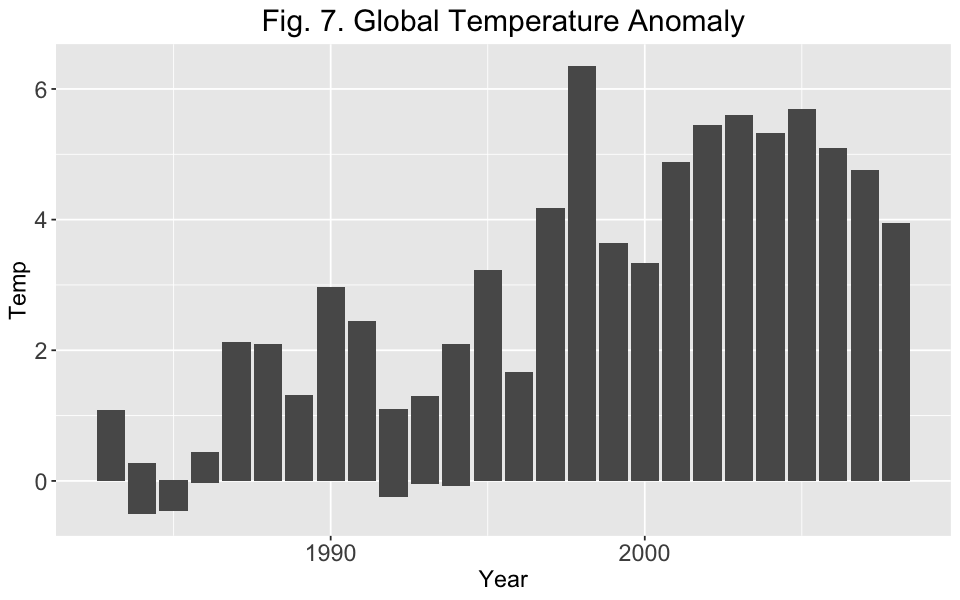

```python
df %>% ggplot(aes(x = Year, y = Temp)) + geom_bar(stat = 'identity') +
ggtitle('Fig. 7. Global Temperature Anomaly') +
theme(axis.title = element_text(size=14), plot.title = element_text(size = 18, hjust = 0.5),
axis.text = element_text(size=14))
```

If we see the correlation matrix below, we observe that some of the features are strongly correlated. If we want to build a model that predicts global temperature anomaly, rather than using all the columns, it would make sense to first apply PCA and consider only the PCs that explain large portion of the variability in the data (for example 99% of the variance: this depends on the application. In some case 90% or 95% of the variance could be enough.)

#### Correlation matrix

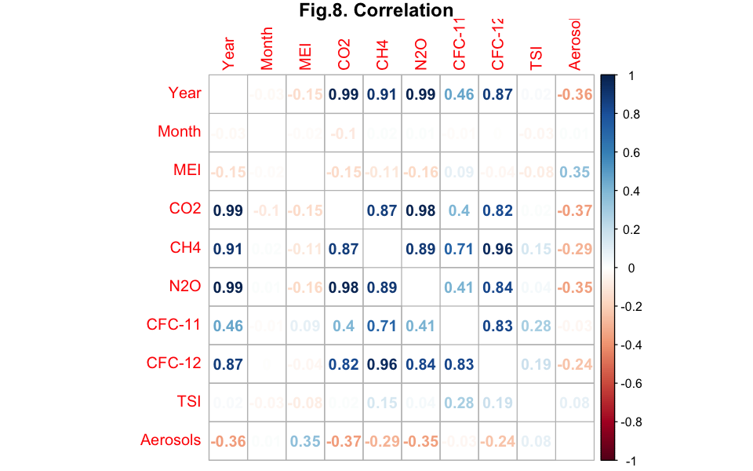

```python
correlations = cor(df %>% select(-Temp))
corrplot(correlations, method="number", diag=FALSE,  title = 'Fig.8. Correlation', mar=c(0,0,1,0))
```

As shown below, the last four PCs explain less than 1% of the variance. So we can safely exclude them from our modeling efforts.

#### Apply PCA

Now, since the variables have different units, I am also standardizing the data by setting scale. = TRUE

```python
pca1 = prcomp(df %>% select(-Temp), center = TRUE, scale. = TRUE)
```

```r
scaled = scale(df %>% select(-Temp), center = TRUE, scale = TRUE)
my_svd  = svd(scaled)
all(pca1$x, my_svd$v)
```

TRUE

#### Variance Explained

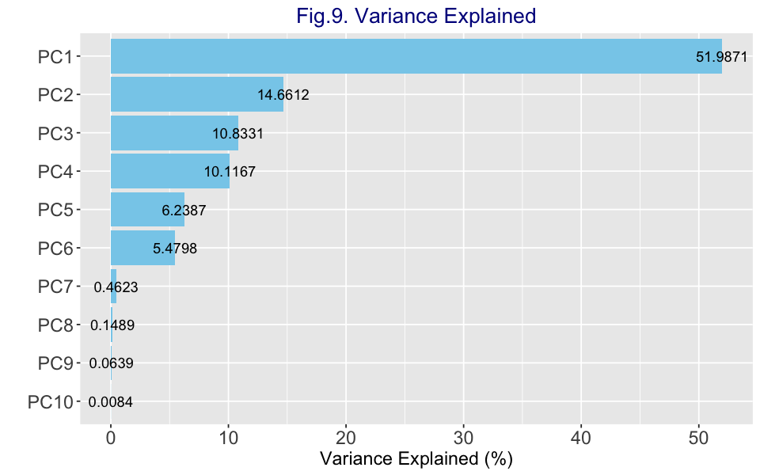

```python
variance = data_frame(PC = paste0('PC', seq(1,10)), variance = round(100.00*pca1$sdev^2/sum(pca1$sdev^2),4)) %>%
mutate(PC = factor(PC,levels = PC[order(variance,decreasing =F)]))
variance %>% ggplot(aes(x = PC, y = variance)) + geom_bar(stat = 'identity', fill = 'skyblue') + ggtitle('Fig.9. Variance Explained') +
theme(axis.title = element_text(size=14), plot.title = element_text(size = 16,colour="darkblue", hjust = 0.5),
axis.text = element_text(size=14)) + geom_text(aes(label = variance), hjust =0.5) + xlab('') +
ylab('Variance Explained (%)') + coord_flip()
```

#### Loadings

I have shown the loadings so that we can compare the rsults from Python, R and Spark.

```python
pca1$rotation
```

|  | PC1 | PC2 | PC3 | PC4 | PC5 | PC6 | PC7 | PC8 | PC9 | PC10 |
| --- | --- | --- | --- | --- | --- | --- | --- | --- | --- | --- |
| Year | 0.42372152 | -0.101430149 | 0.126961941 | -0.021234271 | 0.20360020 | -0.09163459 | 0.155560697 | -0.3187044994 | 0.045801476 | -0.784781733 |
| Month | -0.01096763 | -0.009130275 | 0.069637717 | 0.988558739 | 0.03185540 | -0.09064809 | 0.053960653 | 0.0700018022 | 0.018137666 | -0.018048143 |
| MEI | -0.06970182 | 0.512544079 | 0.583419964 | -0.082195428 | -0.20999249 | -0.58334696 | -0.028557221 | 0.0009738007 | -0.009910770 | -0.000268244 |
| CO2 | 0.41282519 | -0.134071671 | 0.126421173 | -0.097119066 | 0.24746761 | -0.13222613 | 0.300674252 | 0.7631809133 | 0.155782348 | 0.101703011 |
| CH4 | 0.42620306 | 0.092037301 | 0.010714158 | 0.049177493 | -0.02817564 | 0.08700325 | -0.877832876 | 0.1637662716 | 0.007739435 | -0.038904888 |
| N2O | 0.41696055 | -0.120061439 | 0.115263344 | 0.014041136 | 0.27154253 | -0.13420319 | 0.079585969 | -0.3456131306 | -0.602985088 | 0.465969029 |
| CFC-11 | 0.28620883 | 0.459561315 | -0.138013434 | 0.046555320 | -0.49176949 | 0.39555524 | 0.278148854 | 0.1735457501 | -0.400037954 | -0.140912522 |
| CFC-12 | 0.41915551 | 0.195135349 | -0.009326607 | 0.035723551 | -0.14275146 | 0.13813145 | 0.165347962 | -0.3669164468 | 0.670245092 | 0.366351353 |
| TSI | 0.05914216 | 0.381070440 | -0.747974711 | 0.003267360 | 0.21024422 | -0.49680802 | 0.005938048 | 0.0052837562 | 0.004598767 | -0.026561477 |
| Aerosols | -0.16866246 | 0.539978903 | 0.175125080 | 0.006534461 | 0.68647511 | 0.42150455 | -0.001455558 | 0.0062914905 | 0.016612480 | -0.005694819 |

Let's see a sample of the PCs and check if they are uncorrelated.

```python
head(pca1$x, 10)
```

| PC1 | PC2 | PC3 | PC4 | PC5 | PC6 | PC7 | PC8 | PC9 | PC10 |
| --- | --- | --- | --- | --- | --- | --- | --- | --- | --- |
| -5.501971 | 1.0339413 | 1.577995080 | -0.8329917 | 1.905559 | -1.5937319 | -0.04031107 | 0.08401643 | 0.1947381 | -0.003157775 |
| -5.464534 | 0.7238345 | 1.270895220 | -0.5124210 | 1.824382 | -1.4889954 | 0.08645637 | 0.04947770 | 0.1917896 | 0.004471713 |
| -5.396151 | 0.5639044 | 0.662563858 | -0.1753528 | 1.819423 | -1.5143866 | 0.11118147 | -0.02288828 | 0.1839358 | -0.009963323 |
| -5.351135 | 0.2881193 | -0.009440106 | 0.1804583 | 1.842019 | -1.3778205 | 0.15511721 | -0.13228010 | 0.1717102 | -0.026021777 |
| -5.179123 | -0.2977380 | -0.130146309 | 0.5633040 | 1.710963 | -0.7415553 | -0.16777100 | -0.19017270 | 0.1548563 | -0.037085726 |
| -4.971867 | -0.7413673 | -0.077452919 | 0.9033250 | 1.579124 | -0.3131204 | -0.41511568 | -0.11985151 | 0.1603810 | -0.030015376 |
| -4.912814 | -0.8820697 | -0.278511184 | 1.1925655 | 1.555841 | -0.3605595 | -0.24208839 | -0.05333242 | 0.1760971 | -0.012599492 |
| -4.862839 | -1.0045988 | -0.183518060 | 1.4646812 | 1.465730 | -0.3921397 | -0.10133160 | 0.03813628 | 0.1939993 | 0.010334236 |
| -4.735988 | -1.7327242 | 0.684291375 | -1.6846181 | 1.012475 | 0.7364242 | -0.31006936 | -0.16720679 | 0.1437004 | 0.016593883 |
| -4.647267 | -1.6978402 | 0.105830233 | -1.3831074 | 1.117119 | 0.5057776 | -0.20800690 | -0.11576523 | 0.1533069 | 0.012226961 |

```python
round(cor(pca1$x),10)
```

|  | PC1 | PC2 | PC3 | PC4 | PC5 | PC6 | PC7 | PC8 | PC9 | PC10 |
| --- | --- | --- | --- | --- | --- | --- | --- | --- | --- | --- |
| PC1 | 1 | 0 | 0 | 0 | 0 | 0 | 0 | 0 | 0 | 0 |
| PC2 | 0 | 1 | 0 | 0 | 0 | 0 | 0 | 0 | 0 | 0 |
| PC3 | 0 | 0 | 1 | 0 | 0 | 0 | 0 | 0 | 0 | 0 |
| PC4 | 0 | 0 | 0 | 1 | 0 | 0 | 0 | 0 | 0 | 0 |
| PC5 | 0 | 0 | 0 | 0 | 1 | 0 | 0 | 0 | 0 | 0 |
| PC6 | 0 | 0 | 0 | 0 | 0 | 1 | 0 | 0 | 0 | 0 |
| PC7 | 0 | 0 | 0 | 0 | 0 | 0 | 1 | 0 | 0 | 0 |
| PC8 | 0 | 0 | 0 | 0 | 0 | 0 | 0 | 1 | 0 | 0 |
| PC9 | 0 | 0 | 0 | 0 | 0 | 0 | 0 | 0 | 1 | 0 |
| PC10 | 0 | 0 | 0 | 0 | 0 | 0 | 0 | 0 | 0 | 1 |

As expected, they are uncorrelated as shown in the table above.

### Python

```python
df = pd.read_csv('https://courses.edx.org/asset-v1:MITx+15.071x_2a+2T2015+type@asset+block/climate_change.csv')
```

```python
df.head()
```

|  | Year | Month | MEI | CO2 | CH4 | N2O | CFC-11 | CFC-12 | TSI | Aerosols | Temp |
| --- | --- | --- | --- | --- | --- | --- | --- | --- | --- | --- | --- |
| 0 | 1983 | 5 | 2.556 | 345.96 | 1638.59 | 303.677 | 191.324 | 350.113 | 1366.1024 | 0.0863 | 0.109 |
| 1 | 1983 | 6 | 2.167 | 345.52 | 1633.71 | 303.746 | 192.057 | 351.848 | 1366.1208 | 0.0794 | 0.118 |
| 2 | 1983 | 7 | 1.741 | 344.15 | 1633.22 | 303.795 | 192.818 | 353.725 | 1366.2850 | 0.0731 | 0.137 |
| 3 | 1983 | 8 | 1.130 | 342.25 | 1631.35 | 303.839 | 193.602 | 355.633 | 1366.4202 | 0.0673 | 0.176 |
| 4 | 1983 | 9 | 0.428 | 340.17 | 1648.40 | 303.901 | 194.392 | 357.465 | 1366.2335 | 0.0619 | 0.149 |

```python
df = df.drop('Temp', axis = 1)
```

Now, since the variables have different units, I am also standardizing the data by setting with_std=True.

#### Center and standardize data

```python
scaled = scale(df, with_mean=True, with_std=True)
scaled[:10,:]
```

```
array([[-1.70855544, -0.45093617,  2.43534589, -1.3674928 , -2.41935872,
        -1.67058335, -3.00259074, -2.55333892,  0.07930841,  2.40128134],
       [-1.70855544, -0.16037479,  2.01992275, -1.40233993, -2.52549908,
        -1.65735645, -2.96630166, -2.52328676,  0.12542829,  2.16336977],
       [-1.70855544,  0.13018659,  1.56498635, -1.51084122, -2.53615661,
        -1.64796344, -2.92862636, -2.490775  ,  0.53699806,  1.94614617],
       [-1.70855544,  0.42074798,  0.91248367, -1.66131748, -2.57682925,
        -1.63952889, -2.88981239, -2.45772628,  0.87587889,  1.74616253],
       [-1.70855544,  0.71130936,  0.16279974, -1.82604937, -2.20599051,
        -1.62764385, -2.85070138, -2.42599396,  0.40791253,  1.55997087],
       [-1.70855544,  1.00187074, -0.29213666, -1.81575363, -1.87125689,
        -1.61441695, -2.81213495, -2.39639215, -0.02972499,  1.38757118],
       [-1.70855544,  1.29243213, -0.48222745, -1.71834006, -1.9921873 ,
        -1.60253191, -2.77500423, -2.36895547,  0.09133969,  1.23241147],
       [-1.70855544,  1.58299351, -0.48222745, -1.59637509, -2.07744758,
        -1.5929472 , -2.74094299, -2.34442875, -0.02521326,  1.10138771],
       [-1.57362337, -1.6131817 , -0.65629936, -1.51876103, -1.97587474,
        -1.58374587, -2.71074335, -2.32390321, -1.6158477 ,  0.98070793],
       [-1.57362337, -1.32262032, -0.8976506 , -1.46173845, -2.03024992,
        -1.57147744, -2.68400924, -2.30767331, -1.02506211,  0.86002815]])
```

#### Apply PCA

```python
model = PCA()
model.fit(scaled)
transformed = model.transform(scaled)
```

The variance explained, loadings and PCs are the same with those that we got from R above. I have shown samples from each below for cross-checking with the results from R.

#### Variance explained

```python
np.round(model.explained_variance_ratio_ * 100,4)
```

```
array([51.9871, 14.6612, 10.8331, 10.1167,  6.2387,  5.4798,  0.4623,
        0.1489,  0.0639,  0.0084])
```

#### Loadings

Note the loadings matrix is a transpose of that of what we get from R and Spark.

```python
np.round(model.components_,4)
```

```
array([[-0.4237,  0.011 ,  0.0697, -0.4128, -0.4262, -0.417 , -0.2862,
        -0.4192, -0.0591,  0.1687],
       [-0.1014, -0.0091,  0.5125, -0.1341,  0.092 , -0.1201,  0.4596,
         0.1951,  0.3811,  0.54  ],
       [-0.127 , -0.0696, -0.5834, -0.1264, -0.0107, -0.1153,  0.138 ,
         0.0093,  0.748 , -0.1751],
       [-0.0212,  0.9886, -0.0822, -0.0971,  0.0492,  0.014 ,  0.0466,
         0.0357,  0.0033,  0.0065],
       [ 0.2036,  0.0319, -0.21  ,  0.2475, -0.0282,  0.2715, -0.4918,
        -0.1428,  0.2102,  0.6865],
       [-0.0916, -0.0906, -0.5833, -0.1322,  0.087 , -0.1342,  0.3956,
         0.1381, -0.4968,  0.4215],
       [ 0.1556,  0.054 , -0.0286,  0.3007, -0.8778,  0.0796,  0.2781,
         0.1653,  0.0059, -0.0015],
       [-0.3187,  0.07  ,  0.001 ,  0.7632,  0.1638, -0.3456,  0.1735,
        -0.3669,  0.0053,  0.0063],
       [-0.0458, -0.0181,  0.0099, -0.1558, -0.0077,  0.603 ,  0.4   ,
        -0.6702, -0.0046, -0.0166],
       [ 0.7848,  0.018 ,  0.0003, -0.1017,  0.0389, -0.466 ,  0.1409,
        -0.3664,  0.0266,  0.0057]])
```

#### Sample from the PCs

```python
transformed = np.round(transformed, 5)
transformed[:10,:6]
```

```
array([[ 5.51092,  1.03562, -1.58056, -0.83435,  1.90866, -1.59633],
       [ 5.47343,  0.72501, -1.27296, -0.51325,  1.82735, -1.49142],
       [ 5.40493,  0.56482, -0.66364, -0.17564,  1.82238, -1.51685],
       [ 5.35984,  0.28859,  0.00946,  0.18075,  1.84502, -1.38006],
       [ 5.18755, -0.29822,  0.13036,  0.56422,  1.71375, -0.74276],
       [ 4.97996, -0.74257,  0.07758,  0.9048 ,  1.58169, -0.31363],
       [ 4.92081, -0.88351,  0.27896,  1.19451,  1.55837, -0.36115],
       [ 4.87075, -1.00623,  0.18382,  1.46706,  1.46812, -0.39278],
       [ 4.7437 , -1.73554, -0.6854 , -1.68736,  1.01412,  0.73762],
       [ 4.65483, -1.7006 , -0.106  , -1.38536,  1.11894,  0.5066 ]])
```

And finally, shown are the correlations between the different PCs (as expected they are orthogonal to each other that is their correlations are zero).

```python
np.round(np.corrcoef(transformed, rowvar=False), 4)
```

```
array([[ 1.,  0.,  0., -0., -0., -0.,  0., -0.,  0.,  0.],
       [ 0.,  1., -0., -0., -0.,  0.,  0.,  0.,  0., -0.],
       [ 0., -0.,  1., -0.,  0., -0.,  0., -0., -0., -0.],
       [-0., -0., -0.,  1., -0.,  0.,  0., -0., -0.,  0.],
       [-0., -0.,  0., -0.,  1., -0., -0.,  0., -0.,  0.],
       [-0.,  0., -0.,  0., -0.,  1., -0., -0.,  0., -0.],
       [ 0.,  0.,  0.,  0., -0., -0.,  1.,  0., -0.,  0.],
       [-0.,  0., -0., -0.,  0., -0.,  0.,  1., -0., -0.],
       [ 0.,  0., -0., -0., -0.,  0., -0., -0.,  1.,  0.],
       [ 0., -0., -0.,  0.,  0., -0.,  0., -0.,  0.,  1.]])
```

### Spark

```python
df = pd.read_csv('https://courses.edx.org/asset-v1:MITx+15.071x_2a+2T2015+type@asset+block/climate_change.csv')
spark_df = spark.createDataFrame(df)
spark_df.printSchema()
```

```
root
 |-- Year: long (nullable = true)
 |-- Month: long (nullable = true)
 |-- MEI: double (nullable = true)
 |-- CO2: double (nullable = true)
 |-- CH4: double (nullable = true)
 |-- N2O: double (nullable = true)
 |-- CFC-11: double (nullable = true)
 |-- CFC-12: double (nullable = true)
 |-- TSI: double (nullable = true)
 |-- Aerosols: double (nullable = true)
 |-- Temp: double (nullable = true)
```

```python
spark_df.show(5)
```

```
+----+-----+------------------+------+-------+-------+------------------+------------------+---------+--------+-------------------+
|Year|Month|               MEI|   CO2|    CH4|    N2O|            CFC-11|            CFC-12|      TSI|Aerosols|               Temp|
+----+-----+------------------+------+-------+-------+------------------+------------------+---------+--------+-------------------+
|1983|    5|             2.556|345.96|1638.59|303.677|           191.324|350.11300000000006|1366.1024|  0.0863|              0.109|
|1983|    6|             2.167|345.52|1633.71|303.746|192.05700000000002|           351.848|1366.1208|  0.0794|0.11800000000000001|
|1983|    7|1.7409999999999999|344.15|1633.22|303.795|192.81799999999998|           353.725| 1366.285|  0.0731|0.13699999999999998|
|1983|    8|              1.13|342.25|1631.35|303.839|           193.602|355.63300000000004|1366.4202|  0.0673|0.17600000000000002|
|1983|    9|             0.428|340.17| 1648.4|303.901|           194.392|           357.465|1366.2335|  0.0619|              0.149|
+----+-----+------------------+------+-------+-------+------------------+------------------+---------+--------+-------------------+
only showing top 5 rows
```

We create a single vector column following the same steps we did in the first case above. But now we will center and standardize the data before applying PCA. We do not need to include temperature in the features vector. We want to perform PCA over the other variables.

```python
cols = spark_df.drop('Temp').columns
cols
```

```
['Year',
 'Month',
 'MEI',
 'CO2',
 'CH4',
 'N2O',
 'CFC-11',
 'CFC-12',
 'TSI',
 'Aerosols']
```

#### Create a single vector column

```python
assembler = VectorAssembler(inputCols=cols, outputCol = 'features')
output_dat = assembler.transform(spark_df).select('Temp', 'features')
output_dat.show(5, truncate = False)
```

```
+-------------------+-------------------------------------------------------------------------------------------------+
|Temp               |features                                                                                         |
+-------------------+-------------------------------------------------------------------------------------------------+
|0.109              |[1983.0,5.0,2.556,345.96,1638.59,303.677,191.324,350.11300000000006,1366.1024,0.0863]            |
|0.11800000000000001|[1983.0,6.0,2.167,345.52,1633.71,303.746,192.05700000000002,351.848,1366.1208,0.0794]            |
|0.13699999999999998|[1983.0,7.0,1.7409999999999999,344.15,1633.22,303.795,192.81799999999998,353.725,1366.285,0.0731]|
|0.17600000000000002|[1983.0,8.0,1.13,342.25,1631.35,303.839,193.602,355.63300000000004,1366.4202,0.0673]             |
|0.149              |[1983.0,9.0,0.428,340.17,1648.4,303.901,194.392,357.465,1366.2335,0.0619]                        |
+-------------------+-------------------------------------------------------------------------------------------------+
only showing top 5 rows
```

Again, since the variables have different columns, we standardize the data by passing withStd=True.

```python
scaler = StandardScaler(inputCol="features", outputCol="scaledFeatures", withStd=True, withMean=True)

# Compute summary statistics by fitting the StandardScaler
scalerModel = scaler.fit(output_dat)

# Normalize each feature to have unit standard deviation.
scaledData = scalerModel.transform(output_dat)
scaledData.select(['Temp', 'scaledFeatures']).show(5, truncate = False)
```

```
+-------------------+------------------------------------------------------------------------------------------------------------------------------------------------------------------------------------------------------+
|Temp               |scaledFeatures                                                                                                                                                                                        |
+-------------------+------------------------------------------------------------------------------------------------------------------------------------------------------------------------------------------------------+
|0.109              |[-1.7057795516992311,-0.4502035379206733,2.4313891926587416,-1.3652710347365942,-2.4154279983741436,-1.6678691628022873,-2.9977124436890463,-2.5491905227480887,0.07917956200444579,2.397379982283792]|
|0.11800000000000001|[-1.7057795516992311,-0.16011422896760338,2.0166409848574762,-1.4000615507473013,-2.5213959063151057,-1.6546637515752542,-2.96148232034013,-2.5191871845960523,0.125224507701005,2.1598549501929054]  |
|0.13699999999999998|[-1.7057795516992311,0.1299750799854665,1.562443718730641,-1.5083865665079128,-2.53203612657967,-1.6452859957763346,-2.923868235935596,-2.486728241822926,0.5361255991907815,1.9429842687186178]      |
|0.17600000000000002|[-1.7057795516992311,0.42006438893853637,0.9110011609759548,-1.6586183401905104,-2.572642681466886,-1.636865153834457,-2.885117326378228,-2.4537332163508294,0.8744558523536182,1.7433255460914958]   |
|0.149              |[-1.7057795516992311,0.7101536978916063,0.16253524355567714,-1.8230825976956706,-2.2024064457305204,-1.624999422007259,-2.8460698537375144,-2.4220524581407252,0.4072498000938525,1.5574363905421065] |
+-------------------+------------------------------------------------------------------------------------------------------------------------------------------------------------------------------------------------------+
only showing top 5 rows
```

#### Apply PCA

```python
pca = PCA(k=10, inputCol = scaler.getOutputCol(), outputCol="pcaFeatures")

model = pca.fit(scaledData)
transformed_feature = model.transform(scaledData)
```

#### The variance explained are the same with R, scikit-learn and Spark

```python
np.round(100.00*model.explainedVariance.toArray(),4)
```

```
array([5.19871e+01, 1.46612e+01, 1.08331e+01, 1.01167e+01, 6.23870e+00,
       5.47980e+00, 4.62300e-01, 1.48900e-01, 6.39000e-02, 8.40000e-03])
```

#### The eigenvectors are the same with R, scikit-learn and Spark

```python
pcs = np.round(model.pc.toArray(),4)
pcs
```

```
array([[-4.237e-01,  1.014e-01, -1.270e-01, -2.120e-02,  2.036e-01,
         9.160e-02,  1.556e-01, -3.187e-01, -4.580e-02,  7.848e-01],
       [ 1.100e-02,  9.100e-03, -6.960e-02,  9.886e-01,  3.190e-02,
         9.060e-02,  5.400e-02,  7.000e-02, -1.810e-02,  1.800e-02],
       [ 6.970e-02, -5.125e-01, -5.834e-01, -8.220e-02, -2.100e-01,
         5.833e-01, -2.860e-02,  1.000e-03,  9.900e-03,  3.000e-04],
       [-4.128e-01,  1.341e-01, -1.264e-01, -9.710e-02,  2.475e-01,
         1.322e-01,  3.007e-01,  7.632e-01, -1.558e-01, -1.017e-01],
       [-4.262e-01, -9.200e-02, -1.070e-02,  4.920e-02, -2.820e-02,
        -8.700e-02, -8.778e-01,  1.638e-01, -7.700e-03,  3.890e-02],
       [-4.170e-01,  1.201e-01, -1.153e-01,  1.400e-02,  2.715e-01,
         1.342e-01,  7.960e-02, -3.456e-01,  6.030e-01, -4.660e-01],
       [-2.862e-01, -4.596e-01,  1.380e-01,  4.660e-02, -4.918e-01,
        -3.956e-01,  2.781e-01,  1.735e-01,  4.000e-01,  1.409e-01],
       [-4.192e-01, -1.951e-01,  9.300e-03,  3.570e-02, -1.428e-01,
        -1.381e-01,  1.653e-01, -3.669e-01, -6.702e-01, -3.664e-01],
       [-5.910e-02, -3.811e-01,  7.480e-01,  3.300e-03,  2.102e-01,
         4.968e-01,  5.900e-03,  5.300e-03, -4.600e-03,  2.660e-02],
       [ 1.687e-01, -5.400e-01, -1.751e-01,  6.500e-03,  6.865e-01,
        -4.215e-01, -1.500e-03,  6.300e-03, -1.660e-02,  5.700e-03]])
```

```python
cols[:-1]
```

```
['Year', 'Month', 'MEI', 'CO2', 'CH4', 'N2O', 'CFC-11', 'CFC-12', 'TSI']
```

```python
pcs = np.round(model.pc.toArray(),4)
df_pc = pd.DataFrame(pcs, columns = ['PC'+str(i) for i in range(1, 11)], index = cols)
df_pc
```

|  | PC1 | PC2 | PC3 | PC4 | PC5 | PC6 | PC7 | PC8 | PC9 | PC10 |
| --- | --- | --- | --- | --- | --- | --- | --- | --- | --- | --- |
| Year | -0.4237 | 0.1014 | -0.1270 | -0.0212 | 0.2036 | 0.0916 | 0.1556 | -0.3187 | -0.0458 | 0.7848 |
| Month | 0.0110 | 0.0091 | -0.0696 | 0.9886 | 0.0319 | 0.0906 | 0.0540 | 0.0700 | -0.0181 | 0.0180 |
| MEI | 0.0697 | -0.5125 | -0.5834 | -0.0822 | -0.2100 | 0.5833 | -0.0286 | 0.0010 | 0.0099 | 0.0003 |
| CO2 | -0.4128 | 0.1341 | -0.1264 | -0.0971 | 0.2475 | 0.1322 | 0.3007 | 0.7632 | -0.1558 | -0.1017 |
| CH4 | -0.4262 | -0.0920 | -0.0107 | 0.0492 | -0.0282 | -0.0870 | -0.8778 | 0.1638 | -0.0077 | 0.0389 |
| N2O | -0.4170 | 0.1201 | -0.1153 | 0.0140 | 0.2715 | 0.1342 | 0.0796 | -0.3456 | 0.6030 | -0.4660 |
| CFC-11 | -0.2862 | -0.4596 | 0.1380 | 0.0466 | -0.4918 | -0.3956 | 0.2781 | 0.1735 | 0.4000 | 0.1409 |
| CFC-12 | -0.4192 | -0.1951 | 0.0093 | 0.0357 | -0.1428 | -0.1381 | 0.1653 | -0.3669 | -0.6702 | -0.3664 |
| TSI | -0.0591 | -0.3811 | 0.7480 | 0.0033 | 0.2102 | 0.4968 | 0.0059 | 0.0053 | -0.0046 | 0.0266 |
| Aerosols | 0.1687 | -0.5400 | -0.1751 | 0.0065 | 0.6865 | -0.4215 | -0.0015 | 0.0063 | -0.0166 | 0.0057 |

```python
df_pc['PC1']
```

```
Year       -0.4237
Month       0.0110
MEI         0.0697
CO2        -0.4128
CH4        -0.4262
N2O        -0.4170
CFC-11     -0.2862
CFC-12     -0.4192
TSI        -0.0591
Aerosols    0.1687
Name: PC1, dtype: float64
```

#### Sample of PCs are shown below

```python
transformed_feature.select('pcaFeatures').show(10, truncate = False)
```

```
+---------------------------------------------------------------------------------------------------------------------------------------------------------------------------------------------------------+
|pcaFeatures                                                                                                                                                                                              |
+---------------------------------------------------------------------------------------------------------------------------------------------------------------------------------------------------------+
|[5.501970988036319,-1.0339413052599669,-1.5779950804219005,-0.8329916610554952,1.905559430787071,1.5937319453831604,-0.040311068906294024,0.08401643092962642,-0.1947381261185601,0.0031577752934403604] |
|[5.464533785859468,-0.7238344699646873,-1.2708952200903347,-0.512421049941966,1.8243821396706783,1.488995386392944,0.08645636889783163,0.04947770224364972,-0.19178963291899198,-0.004471712810394072]   |
|[5.396150685687981,-0.5639043994189652,-0.6625638583859077,-0.1753528376049104,1.8194226212666482,1.5143865821023716,0.11118147154420345,-0.022888284271145986,-0.18393576320208865,0.009963323270281058]|
|[5.351135069459403,-0.2881193423385541,0.009440106330036224,0.18045830754316122,1.8420194443860776,1.3778204953122357,0.1551172099415107,-0.13228010320613748,-0.17171022589408977,0.026021776908695674] |
|[5.179123011662285,0.2977379967589393,0.13014630947227213,0.5633040196980976,1.7109629237749036,0.7415552810012943,-0.16777099711697904,-0.1901727034830199,-0.15485632439349653,0.03708572636050115]    |
|[4.971866889441485,0.741367269937696,0.07745291896203116,0.9033250401845025,1.5791244883311593,0.31312042974478416,-0.41511567976033914,-0.11985150942562203,-0.16038098430098524,0.03001537597365217]   |
|[4.912813603109937,0.8820696614468595,0.27851118414255716,1.1925654904710319,1.5558407452053475,0.3605594579773356,-0.2420883932092398,-0.053332415261254124,-0.17609710166217932,0.012599491535068664]  |
|[4.862838501906219,1.0045987886639711,0.18351805990818507,1.4646811534080195,1.4657299929747274,0.39213973382144796,-0.10133160373094202,0.03813627815698469,-0.19399925557866216,-0.010334236110436011] |
|[4.735988057456969,1.7327241635070392,-0.6842913749719202,-1.6846181355507792,1.0124751106517054,-0.7364241943974421,-0.31006936274220503,-0.1672067904110762,-0.14370037531244229,-0.016593883394504322]|
|[4.647266766730869,1.6978402250148208,-0.10583023289915289,-1.3831074493047872,1.117119141311163,-0.505777637388481,-0.20800689941704525,-0.11576523213982652,-0.1533068683874168,-0.012226960768979049] |
+---------------------------------------------------------------------------------------------------------------------------------------------------------------------------------------------------------+
only showing top 10 rows
```

For comparing with the results from Python and R, I have rounded the array above.

```python
transformed_feature.select('pcaFeatures').rdd.map(lambda x: Row(pcaFeatures = str([x for x in list(np.round(x[0].\
                                                    toArray(),4))]))).toDF().show(truncate = False)
```

```
+--------------------------------------------------------------------------------------+
|pcaFeatures                                                                           |
+--------------------------------------------------------------------------------------+
|[5.502, -1.0339, -1.578, -0.833, 1.9056, 1.5937, -0.0403, 0.084, -0.1947, 0.0032]     |
|[5.4645, -0.7238, -1.2709, -0.5124, 1.8244, 1.489, 0.0865, 0.0495, -0.1918, -0.0045]  |
|[5.3962, -0.5639, -0.6626, -0.1754, 1.8194, 1.5144, 0.1112, -0.0229, -0.1839, 0.01]   |
|[5.3511, -0.2881, 0.0094, 0.1805, 1.842, 1.3778, 0.1551, -0.1323, -0.1717, 0.026]     |
|[5.1791, 0.2977, 0.1301, 0.5633, 1.711, 0.7416, -0.1678, -0.1902, -0.1549, 0.0371]    |
|[4.9719, 0.7414, 0.0775, 0.9033, 1.5791, 0.3131, -0.4151, -0.1199, -0.1604, 0.03]     |
|[4.9128, 0.8821, 0.2785, 1.1926, 1.5558, 0.3606, -0.2421, -0.0533, -0.1761, 0.0126]   |
|[4.8628, 1.0046, 0.1835, 1.4647, 1.4657, 0.3921, -0.1013, 0.0381, -0.194, -0.0103]    |
|[4.736, 1.7327, -0.6843, -1.6846, 1.0125, -0.7364, -0.3101, -0.1672, -0.1437, -0.0166]|
|[4.6473, 1.6978, -0.1058, -1.3831, 1.1171, -0.5058, -0.208, -0.1158, -0.1533, -0.0122]|
|[4.5723, 0.8943, 0.4063, -1.1581, 1.1647, 0.6322, -0.1656, -0.0562, -0.152, 0.0107]   |
|[4.5815, 1.4205, -0.8621, -0.9008, 0.755, 0.0793, -0.1602, 0.0346, -0.1491, -0.0437]  |
|[4.5535, 1.4011, -0.3419, -0.6076, 0.8684, 0.2946, 0.0532, 0.0681, -0.1512, -0.0476]  |
|[4.6144, 1.2959, 0.42, -0.3054, 1.0381, 0.5952, 0.3701, -0.0027, -0.136, -0.0395]     |
|[4.6613, 1.2904, 0.4629, -0.01, 0.9685, 0.6549, 0.4484, -0.091, -0.101, -0.0368]      |
|[4.5846, 1.4106, 0.2504, 0.3149, 0.7889, 0.4487, 0.1641, -0.1728, -0.0505, -0.0226]   |
|[4.4384, 1.4174, -0.0063, 0.6311, 0.5947, 0.3475, -0.2262, -0.2002, -0.0016, -0.0041] |
|[4.2983, 1.4267, -0.2247, 0.9218, 0.4645, 0.3185, -0.3928, -0.125, 0.023, -0.0063]    |
|[4.1753, 1.7402, -0.2119, 1.2358, 0.4497, -0.0089, -0.3565, -0.0154, 0.0288, -0.0229] |
|[4.1057, 1.8247, 0.0857, 1.533, 0.5248, -0.0264, -0.1793, 0.08, 0.0262, -0.0292]      |
+--------------------------------------------------------------------------------------+
only showing top 20 rows
```

### Final Remarks

1. Unlike in R, in Spark and in Python, you have to center and optionally standardize the data before applying PCA
2. In Spark, unlike that of R and Python, a given list of columns has to be transformed into a single [vector column](https://spark.apache.org/docs/latest/ml-features.html#vectorassembler)
3. The loadings from R and Spark have the same format but in Python they are transposed. So, you have to clearly understand which rows and columns to access while dealing with the loading matrix otherwise you can work with the wrong data.
4. As expected, I got the same results from all the three tools
5. If your variables are in the same unit and with similar scale, use covariance matrix for your PCA (center the data)
6. If your columns are in different units and have different scales, use correlation matrix (center the data and then standardize it so that it will have standard deviation of one and mean of zero)
7. Remember standardizing the data may led to lose of information
8. Once you center and or standardize your data, the matrix is no more sparse.
9. If you are dealing with millions of rows like me, Spark will be your best friend.
10. If you are working with big data and want to apply some algorithm, first understanding the mechanics using small data could save you time and help you avoid mistakes.

[comments powered by Disqus](http://disqus.com)